# WGCNA: an R package for weighted correlation network analysis | BMC Bioinformatics | Full Text

[figure not shown]

[BMC Bioinformatics](https://bmcbioinformatics.biomedcentral.com/)

- Software
- [Open access](https://www.springernature.com/gp/open-research/about/the-fundamentals-of-open-access-and-open-research)
- Published: 29 December 2008

# WGCNA: an R package for weighted correlation network analysis

- Peter Langfelder &
- Steve Horvath

[*BMC Bioinformatics*](https://bmcbioinformatics.biomedcentral.com/) **volume 9**, Article number: 559 (2008) Cite this article

## Abstract

### Background

Correlation networks are increasingly being used in bioinformatics applications. For example, weighted gene co-expression network analysis is a systems biology method for describing the correlation patterns among genes across microarray samples. Weighted correlation network analysis (WGCNA) can be used for finding clusters (modules) of highly correlated genes, for summarizing such clusters using the module eigengene or an intramodular hub gene, for relating modules to one another and to external sample traits (using eigengene network methodology), and for calculating module membership measures. Correlation networks facilitate network based gene screening methods that can be used to identify candidate biomarkers or therapeutic targets. These methods have been successfully applied in various biological contexts, e.g. cancer, mouse genetics, yeast genetics, and analysis of brain imaging data. While parts of the correlation network methodology have been described in separate publications, there is a need to provide a user-friendly, comprehensive, and consistent software implementation and an accompanying tutorial.

### Results

The WGCNA R software package is a comprehensive collection of R functions for performing various aspects of weighted correlation network analysis. The package includes functions for network construction, module detection, gene selection, calculations of topological properties, data simulation, visualization, and interfacing with external software. Along with the R package we also present R software tutorials. While the methods development was motivated by gene expression data, the underlying data mining approach can be applied to a variety of different settings.

### Conclusion

The WGCNA package provides R functions for weighted correlation network analysis, e.g. co-expression network analysis of gene expression data. The R package along with its source code and additional material are freely available at http://www.genetics.ucla.edu/labs/horvath/CoexpressionNetwork/Rpackages/WGCNA.

## Background

We refer to the *i*-th row *x*<sub>*i*</sub>as the *i*-th *node profile* across *m* sample measurements.

Sometimes a quantitative measure (referred to as *sample trait*) is provided for the columns of *X*. For example, *T* = (*T*<sub>1</sub>, . . ., *T*<sub>*m*</sub>) could measure survival time or it could be a binary indicator variable (disease status). Abstractly speaking, we define a sample trait *T* as a vector with *m* components that correspond to the columns of the data matrix *X*. A sample trait can be used to define a node significance measure. For example, a *trait-based node significance measure* can be defined as the absolute value of the correlation between the *i*-th node profile *x*<sub>*i*</sub>and the sample trait

*T*:*GS*<sub>*i*</sub>= |*cor*(*x*<sub>*i*</sub>, *T*)|.(2)

Alternatively, a correlation test p-value [1] or a regression-based p-value for assessing the statistical significance between *x*<sub>*i*</sub>and the sample trait *T* can be used to define a p-value based node significance measure, for example by defining

*GS*<sub>*i*</sub>= -log *p*<sub>*i*</sub>.(3)

The rationale behind correlation network methodology is to use network language to describe the pairwise relationships (correlations) between the rows of *X* (Equation 1). Although other statistical techniques exist for analyzing correlation matrices, network language is particularly intuitive to biologists and allows for simple social network analogies. Correlation networks can be used to address many analysis goals including the following. First, correlation networks can be used to find clusters (modules) of interconnected nodes. Thus, a network module is a set of rows of *X* (Equation 1) which are closely connected according to a suitably defined measure of interconnectedness.

A second analysis goal is to summarize the node profiles of a given module by a representative, e.g. a highly connected hub node, which is centrally located in the module. Focusing the analysis on module or their representatives amounts to a network-based data reduction method. Relating modules instead of nodes to a sample trait can alleviate the multiple testing problem.

A third analysis goal is to identify 'significant' modules. Toward this end, a node significance measure can be used to identify modules with high average node significance (referred to as module significance).

A fourth analysis goal is to annotate all network nodes with respect to how close they are to the identified modules. This can be accomplished by defining a fuzzy measure of module memberships that generalizes the binary module membership indicator to a quantitative measure. Fuzzy measures of module membership can be used to identify nodes that lie intermediate between and close to two or more modules.

A fifth analysis goal is to define the network neighborhood of a given seed set of nodes. Intuitively speaking, a neighborhood is composed of nodes that are highly connected to a given set of nodes. Thus, neighborhood analysis facilitates a guilt-by-association screening strategy for finding nodes that interact with a given set of interesting nodes.

A sixth analysis goal is to screen for nodes based on node screening criteria which can be based on a node significance measure, on module membership information, on network topological properties (e.g. high connectivity), etc.

A seventh analysis goal is to contrast one network with another network. This differential network analysis can be used to identify changes in connectivity patterns or module structure between different conditions. An eighth analysis goal is to find shared modules between two or more networks (consensus module analysis). Since by definition consensus modules are building blocks in multiple networks, they may represent fundamental structural properties of the network.

The above incomplete enumeration of analysis goals shows that correlation networks can be used as a data exploratory technique (similar to cluster analysis, factor analysis, or other dimensional reduction techniques) and as a screening method. For example, correlation networks can be used to screen for modules and intramodular hubs that relate to a sample trait. Correlation networks allow one to generate testable hypotheses that should be validated in independent data or in designed validation experiments.

## Results

Figure 1 provides an overview of typical analysis steps and the rationale behind them. To determine whether a co-expression module is biologically meaningful, one can use functional enrichment and gene ontology information.

**Figure 1**

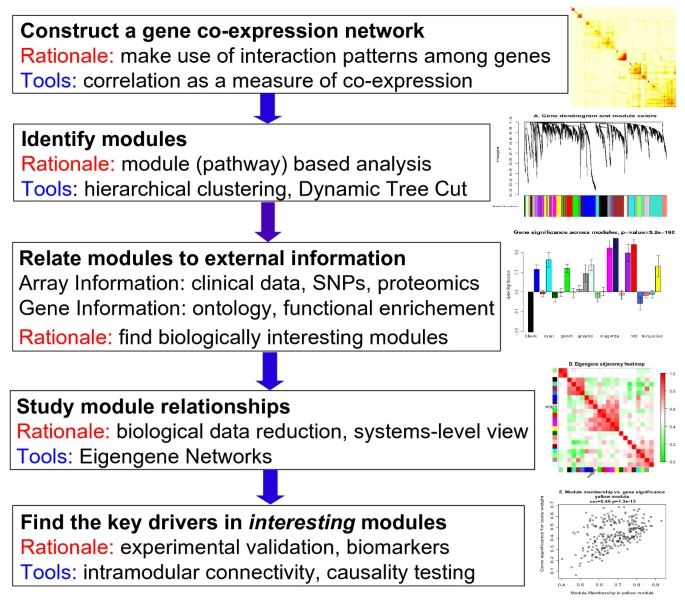

**Overview of WGCNA methodology**. This flowchart presents a brief overview of the main steps of Weighted Gene Co-expression Network Analysis.

[Full size image](https://bmcbioinformatics.biomedcentral.com/articles/10.1186/1471-2105-9-559/figures/1)

### Overview of functions included in the WGCNA package

The WGCNA package contains a comprehensive set of functions for performing a correlation network analysis of large, high-dimensional data sets. Functions in the WGCNA package can be divided into the following categories: 1. network construction; 2. module detection; 3. module and gene selection; 4. calculations of topological properties; 5. data simulation; 6. visualization; 7. interfacing with external software packages. An exhaustive list of implemented functions together with detailed descriptions is provided in the R package manual posted on our web site. Here we briefly outline the main functionality of the package and highlight new contributions.